# Analyzing GEO Microarray Data

How-to-analyze-GEO-microarray-data

## GEO

The Gene Expression Omnibus (GEO) is a data repository hosted by the National Center for Biotechnology Information (NCBI). NCBI contains all publicly available nucleotide and protein sequences.

## GEOquery

```r
getwd()
```

```
[1] "C:/Users/sunzi/Downloads/Research/24-25_LSU Brain/24_12_Tutorial"
```

Install [R tools](https://cran.rstudio.com/bin/windows/Rtools/)

```r
if (!require("BiocManager", quietly = TRUE))
    install.packages("BiocManager")
BiocManager::install("GEOquery")
```

Load `Geoquery`

```r
library(GEOquery)
```

Load data

```r
my_id <- "GSE63477"
gse <- getGEO(my_id)
```

```
Found 1 file(s)
GSE63477_series_matrix.txt.gz
```

```r
length(gse)
```

```
[1] 1
```

```r
gse <- gse[[1]]
gse
```

```
ExpressionSet (storageMode: lockedEnvironment)
assayData: 44629 features, 12 samples
  element names: exprs
protocolData: none
phenoData
  sampleNames: GSM1550559 GSM1550560 ... GSM1550570 (12 total)
  varLabels: title geo_accession ... treatment:ch1 (35 total)
  varMetadata: labelDescription
featureData
  featureNames: 16657436 16657440 ... 17118478 (44629 total)
  fvarLabels: ID RANGE_STRAND ... RANGE_GB (8 total)
  fvarMetadata: Column Description labelDescription
experimentData: use 'experimentData(object)'
Annotation: GPL16686
```

Print sample information

|  | title | geo_accession | status | submission_date | last_update_date | type | channel_count | source_name_ch1 | organism_ch1 | characteristics_ch1 | characteristics_ch1.1 | treatment_protocol_ch1 | growth_protocol_ch1 | molecule_ch1 | extract_protocol_ch1 | label_ch1 | label_protocol_ch1 | taxid_ch1 | hyb_protocol | scan_protocol | data_processing | data_processing.1 | data_processing.2 | platform_id | contact_name | contact_institute | contact_address | contact_city | contact_state | … |
| --- | --- | --- | --- | --- | --- | --- | --- | --- | --- | --- | --- | --- | --- | --- | --- | --- | --- | --- | --- | --- | --- | --- | --- | --- | --- | --- | --- | --- | --- | --- |
| GSM1550559 | LNCaP CTRL treated in charcoal dextran treated serum, replicate 1 | GSM1550559 | Public on Jan 01 2015 | Nov 19 2014 | Jan 01 2015 | RNA | 1 | LNCaP | Homo sapiens | cell line: LNCaP | treatment: CTRL treated in charcoal dextran treated serum | 16h treatment with 1nM cabazitaxel, docetaxel, or control (EtOH) | Cells treated at ca. 80% confluency | total RNA | Standard Trizol RNA extraction, followed by cDNA amplification using the Ovation Pico WTA-system V2 RNA amplification system (NuGen Technologies, Inc) | biotin | 5ug cDNA was fragmanted and chemically labeled with biotin using the FL-Ovation cDNA biotin module (NuGen Technologies, Inc) | 9606 | 5ug cDNA in 220ul hybridization cocktail was hybridized on the Affymetrix Human Gene 2.0 ST Array in a GeneChip Hybridization Oven 645. Target denaturation was performed at 99C for 2 minutes, 45C for … | Affymetrix Gene ChIP Scanner 3000 7G | Data were processed with GenSpring 11.5 software. The expression data were RMA normalized, and filtered to remove low-expressing genes. | HuGene-2_0-st.pgf | HuGene-2_0-st.mps | GPL16686 | Karen,,Knudsen | Thomas Jefferson University - Kimmel Cancer Center | 233 S 10th St, BLSB 1008 | Philadelphia | Pennsylvania | … |
| GSM1550560 | LNCaP CTRL treated in charcoal dextran treated serum, replicate 2 | GSM1550560 | Public on Jan 01 2015 | Nov 19 2014 | Jan 01 2015 | RNA | 1 | LNCaP | Homo sapiens | cell line: LNCaP | treatment: CTRL treated in charcoal dextran treated serum | 16h treatment with 1nM cabazitaxel, docetaxel, or control (EtOH) | Cells treated at ca. 80% confluency | total RNA | Standard Trizol RNA extraction, followed by cDNA amplification using the Ovation Pico WTA-system V2 RNA amplification system (NuGen Technologies, Inc) | biotin | 5ug cDNA was fragmanted and chemically labeled with biotin using the FL-Ovation cDNA biotin module (NuGen Technologies, Inc) | 9606 | 5ug cDNA in 220ul hybridization cocktail was hybridized on the Affymetrix Human Gene 2.0 ST Array in a GeneChip Hybridization Oven 645. Target denaturation was performed at 99C for 2 minutes, 45C for … | Affymetrix Gene ChIP Scanner 3000 7G | Data were processed with GenSpring 11.5 software. The expression data were RMA normalized, and filtered to remove low-expressing genes. | HuGene-2_0-st.pgf | HuGene-2_0-st.mps | GPL16686 | Karen,,Knudsen | Thomas Jefferson University - Kimmel Cancer Center | 233 S 10th St, BLSB 1008 | Philadelphia | Pennsylvania | … |

Print gene annotation

|  | ID | RANGE_STRAND | RANGE_START | RANGE_END | total_probes | GB_ACC | SPOT_ID | RANGE_GB |
| --- | --- | --- | --- | --- | --- | --- | --- | --- |
| 16657436 | 16657436 | + | 12190 | 13639 | 25 | NR_046018 | chr1:12190-13639 | NC_000001.10 |

Print expression data

```r
exprs(gse)[1,]
```

```
GSM1550559 GSM1550560 GSM1550561 GSM1550562 GSM1550563 GSM1550564
  24.63215   21.96198   24.36674   24.28032   24.82574   22.72258
GSM1550565 GSM1550566 GSM1550567 GSM1550568 GSM1550569 GSM1550570
  25.76430   23.03947   24.45452   23.74868   23.77131   21.67176
```

## Check normalization and scales used

To check if data is RMA (Robust Multiarray Average) normalized to remove low-expression gene. Use the ‘summary’ function and check if the data is log transformed, i.e., within (0-16) range. Do the RMA normalization or log transform otherwise.

Performing log2 transform, drawing boxplot. Data is normalized if distributions are similar.

```r
pData(gse)$data_processing[1]
```

```
[1] "Data were processed with GenSpring 11.5 software. The expression data were RMA normalized, and filtered to remove low-expressing genes."
```

```r
summary(exprs(gse))
```

```
   GSM1550559        GSM1550560        GSM1550561
 Min.   :  17.42   Min.   :  17.49   Min.   :  17.54
 1st Qu.:  19.59   1st Qu.:  19.53   1st Qu.:  19.59
 Median :  22.29   Median :  22.34   Median :  22.39
 Mean   :  48.09   Mean   :  48.51   Mean   :  48.08
 3rd Qu.:  33.45   3rd Qu.:  33.90   3rd Qu.:  33.70
 Max.   :5889.83   Max.   :6043.74   Max.   :5907.55
   GSM1550562        GSM1550563        GSM1550564
 Min.   :  17.44   Min.   :  17.48   Min.   :  17.47
 1st Qu.:  19.45   1st Qu.:  19.48   1st Qu.:  19.51
 Median :  22.43   Median :  22.19   Median :  22.22
 Mean   :  48.91   Mean   :  49.16   Mean   :  48.72
 3rd Qu.:  33.92   3rd Qu.:  33.70   3rd Qu.:  33.84
 Max.   :6087.95   Max.   :5991.22   Max.   :5827.09
   GSM1550565        GSM1550566        GSM1550567
 Min.   :  17.43   Min.   :  17.49   Min.   :  17.49
 1st Qu.:  19.59   1st Qu.:  19.54   1st Qu.:  19.54
 Median :  22.38   Median :  22.29   Median :  22.36
 Mean   :  48.29   Mean   :  48.83   Mean   :  48.72
 3rd Qu.:  33.49   3rd Qu.:  33.85   3rd Qu.:  33.62
 Max.   :5704.80   Max.   :5938.88   Max.   :6140.01
   GSM1550568        GSM1550569        GSM1550570
 Min.   :  17.32   Min.   :  17.38   Min.   :  17.38
 1st Qu.:  19.58   1st Qu.:  19.41   1st Qu.:  19.52
 Median :  22.35   Median :  22.31   Median :  22.27
 Mean   :  48.31   Mean   :  49.31   Mean   :  48.94
 3rd Qu.:  33.58   3rd Qu.:  33.82   3rd Qu.:  33.71
 Max.   :6066.52   Max.   :6307.27   Max.   :5844.71
```

```r
summary(exprs(gse))
```

[output not shown]

[figure not shown]

## Inspect the clinical variables

Sample name is stored in column of ‘characteristics_ch1.1’. We can select and rename the column.

```r
sampleInfo <- pData(gse)
head(sampleInfo)
```

|  | title | geo_accession | status | submission_date | last_update_date | type | channel_count | source_name_ch1 | organism_ch1 | characteristics_ch1 | characteristics_ch1.1 | treatment_protocol_ch1 | growth_protocol_ch1 | molecule_ch1 | extract_protocol_ch1 | label_ch1 | label_protocol_ch1 | taxid_ch1 | hyb_protocol | scan_protocol | data_processing | data_processing.1 | data_processing.2 | platform_id | contact_name | contact_institute | contact_address | contact_city | contact_state | … |
| --- | --- | --- | --- | --- | --- | --- | --- | --- | --- | --- | --- | --- | --- | --- | --- | --- | --- | --- | --- | --- | --- | --- | --- | --- | --- | --- | --- | --- | --- | --- |
| GSM1550559 | LNCaP CTRL treated in charcoal dextran treated serum, replicate 1 | GSM1550559 | Public on Jan 01 2015 | Nov 19 2014 | Jan 01 2015 | RNA | 1 | LNCaP | Homo sapiens | cell line: LNCaP | treatment: CTRL treated in charcoal dextran treated serum | 16h treatment with 1nM cabazitaxel, docetaxel, or control (EtOH) | Cells treated at ca. 80% confluency | total RNA | Standard Trizol RNA extraction, followed by cDNA amplification using the Ovation Pico WTA-system V2 RNA amplification system (NuGen Technologies, Inc) | biotin | 5ug cDNA was fragmanted and chemically labeled with biotin using the FL-Ovation cDNA biotin module (NuGen Technologies, Inc) | 9606 | 5ug cDNA in 220ul hybridization cocktail was hybridized on the Affymetrix Human Gene 2.0 ST Array in a GeneChip Hybridization Oven 645. Target denaturation was performed at 99C for 2 minutes, 45C for … | Affymetrix Gene ChIP Scanner 3000 7G | Data were processed with GenSpring 11.5 software. The expression data were RMA normalized, and filtered to remove low-expressing genes. | HuGene-2_0-st.pgf | HuGene-2_0-st.mps | GPL16686 | Karen,,Knudsen | Thomas Jefferson University - Kimmel Cancer Center | 233 S 10th St, BLSB 1008 | Philadelphia | Pennsylvania | … |
| GSM1550560 | LNCaP CTRL treated in charcoal dextran treated serum, replicate 2 | GSM1550560 | Public on Jan 01 2015 | Nov 19 2014 | Jan 01 2015 | RNA | 1 | LNCaP | Homo sapiens | cell line: LNCaP | treatment: CTRL treated in charcoal dextran treated serum | 16h treatment with 1nM cabazitaxel, docetaxel, or control (EtOH) | Cells treated at ca. 80% confluency | total RNA | Standard Trizol RNA extraction, followed by cDNA amplification using the Ovation Pico WTA-system V2 RNA amplification system (NuGen Technologies, Inc) | biotin | 5ug cDNA was fragmanted and chemically labeled with biotin using the FL-Ovation cDNA biotin module (NuGen Technologies, Inc) | 9606 | 5ug cDNA in 220ul hybridization cocktail was hybridized on the Affymetrix Human Gene 2.0 ST Array in a GeneChip Hybridization Oven 645. Target denaturation was performed at 99C for 2 minutes, 45C for … | Affymetrix Gene ChIP Scanner 3000 7G | Data were processed with GenSpring 11.5 software. The expression data were RMA normalized, and filtered to remove low-expressing genes. | HuGene-2_0-st.pgf | HuGene-2_0-st.mps | GPL16686 | Karen,,Knudsen | Thomas Jefferson University - Kimmel Cancer Center | 233 S 10th St, BLSB 1008 | Philadelphia | Pennsylvania | … |
| GSM1550561 | LNCaP 16h cabazitaxel (1nM) treated in charcoal dextran treated serum, replicate 1 | GSM1550561 | Public on Jan 01 2015 | Nov 19 2014 | Jan 01 2015 | RNA | 1 | LNCaP | Homo sapiens | cell line: LNCaP | treatment: 16h cabazitaxel (1nM) treated in charcoal dextran treated serum | 16h treatment with 1nM cabazitaxel, docetaxel, or control (EtOH) | Cells treated at ca. 80% confluency | total RNA | Standard Trizol RNA extraction, followed by cDNA amplification using the Ovation Pico WTA-system V2 RNA amplification system (NuGen Technologies, Inc) | biotin | 5ug cDNA was fragmanted and chemically labeled with biotin using the FL-Ovation cDNA biotin module (NuGen Technologies, Inc) | 9606 | 5ug cDNA in 220ul hybridization cocktail was hybridized on the Affymetrix Human Gene 2.0 ST Array in a GeneChip Hybridization Oven 645. Target denaturation was performed at 99C for 2 minutes, 45C for … | Affymetrix Gene ChIP Scanner 3000 7G | Data were processed with GenSpring 11.5 software. The expression data were RMA normalized, and filtered to remove low-expressing genes. | HuGene-2_0-st.pgf | HuGene-2_0-st.mps | GPL16686 | Karen,,Knudsen | Thomas Jefferson University - Kimmel Cancer Center | 233 S 10th St, BLSB 1008 | Philadelphia | Pennsylvania | … |
| GSM1550562 | LNCaP 16h cabazitaxel (1nM) treated in charcoal dextran treated serum, replicate 2 | GSM1550562 | Public on Jan 01 2015 | Nov 19 2014 | Jan 01 2015 | RNA | 1 | LNCaP | Homo sapiens | cell line: LNCaP | treatment: 16h cabazitaxel (1nM) treated in charcoal dextran treated serum | 16h treatment with 1nM cabazitaxel, docetaxel, or control (EtOH) | Cells treated at ca. 80% confluency | total RNA | Standard Trizol RNA extraction, followed by cDNA amplification using the Ovation Pico WTA-system V2 RNA amplification system (NuGen Technologies, Inc) | biotin | 5ug cDNA was fragmanted and chemically labeled with biotin using the FL-Ovation cDNA biotin module (NuGen Technologies, Inc) | 9606 | 5ug cDNA in 220ul hybridization cocktail was hybridized on the Affymetrix Human Gene 2.0 ST Array in a GeneChip Hybridization Oven 645. Target denaturation was performed at 99C for 2 minutes, 45C for … | Affymetrix Gene ChIP Scanner 3000 7G | Data were processed with GenSpring 11.5 software. The expression data were RMA normalized, and filtered to remove low-expressing genes. | HuGene-2_0-st.pgf | HuGene-2_0-st.mps | GPL16686 | Karen,,Knudsen | Thomas Jefferson University - Kimmel Cancer Center | 233 S 10th St, BLSB 1008 | Philadelphia | Pennsylvania | … |
| GSM1550563 | LNCaP 16h docetaxel (1nM) treated in charcoal dextran treated serum, replicate 1 | GSM1550563 | Public on Jan 01 2015 | Nov 19 2014 | Jan 01 2015 | RNA | 1 | LNCaP | Homo sapiens | cell line: LNCaP | treatment: 16h docetaxel (1nM) treated in charcoal dextran treated serum | 16h treatment with 1nM cabazitaxel, docetaxel, or control (EtOH) | Cells treated at ca. 80% confluency | total RNA | Standard Trizol RNA extraction, followed by cDNA amplification using the Ovation Pico WTA-system V2 RNA amplification system (NuGen Technologies, Inc) | biotin | 5ug cDNA was fragmanted and chemically labeled with biotin using the FL-Ovation cDNA biotin module (NuGen Technologies, Inc) | 9606 | 5ug cDNA in 220ul hybridization cocktail was hybridized on the Affymetrix Human Gene 2.0 ST Array in a GeneChip Hybridization Oven 645. Target denaturation was performed at 99C for 2 minutes, 45C for … | Affymetrix Gene ChIP Scanner 3000 7G | Data were processed with GenSpring 11.5 software. The expression data were RMA normalized, and filtered to remove low-expressing genes. | HuGene-2_0-st.pgf | HuGene-2_0-st.mps | GPL16686 | Karen,,Knudsen | Thomas Jefferson University - Kimmel Cancer Center | 233 S 10th St, BLSB 1008 | Philadelphia | Pennsylvania | … |
| GSM1550564 | LNCaP 16h docetaxel (1nM) treated in charcoal dextran treated serum, replicate 2 | GSM1550564 | Public on Jan 01 2015 | Nov 19 2014 | Jan 01 2015 | RNA | 1 | LNCaP | Homo sapiens | cell line: LNCaP | treatment: 16h docetaxel (1nM) treated in charcoal dextran treated serum | 16h treatment with 1nM cabazitaxel, docetaxel, or control (EtOH) | Cells treated at ca. 80% confluency | total RNA | Standard Trizol RNA extraction, followed by cDNA amplification using the Ovation Pico WTA-system V2 RNA amplification system (NuGen Technologies, Inc) | biotin | 5ug cDNA was fragmanted and chemically labeled with biotin using the FL-Ovation cDNA biotin module (NuGen Technologies, Inc) | 9606 | 5ug cDNA in 220ul hybridization cocktail was hybridized on the Affymetrix Human Gene 2.0 ST Array in a GeneChip Hybridization Oven 645. Target denaturation was performed at 99C for 2 minutes, 45C for … | Affymetrix Gene ChIP Scanner 3000 7G | Data were processed with GenSpring 11.5 software. The expression data were RMA normalized, and filtered to remove low-expressing genes. | HuGene-2_0-st.pgf | HuGene-2_0-st.mps | GPL16686 | Karen,,Knudsen | Thomas Jefferson University - Kimmel Cancer Center | 233 S 10th St, BLSB 1008 | Philadelphia | Pennsylvania | … |

```r
table(sampleInfo$characteristics_ch1.1)
```

```
treatment: 16h cabazitaxel (1nM) treated in charcoal dextran treated serum
                                                                         2
                    treatment: 16h cabazitaxel (1nM) treated in full serum
                                                                         2
  treatment: 16h docetaxel (1nM) treated in charcoal dextran treated serum
                                                                         2
                      treatment: 16h docetaxel (1nM) treated in full serum
                                                                         2
                 treatment: CTRL treated in charcoal dextran treated serum
                                                                         2
                                     treatment: CTRL treated in full serum
                                                                         2
```

|  | sample |
| --- | --- |
| GSM1550559 | treatment: CTRL treated in charcoal dextran treated serum |
| GSM1550560 | treatment: CTRL treated in charcoal dextran treated serum |
| GSM1550561 | treatment: 16h cabazitaxel (1nM) treated in charcoal dextran treated serum |
| GSM1550562 | treatment: 16h cabazitaxel (1nM) treated in charcoal dextran treated serum |
| GSM1550563 | treatment: 16h docetaxel (1nM) treated in charcoal dextran treated serum |
| GSM1550564 | treatment: 16h docetaxel (1nM) treated in charcoal dextran treated serum |

```r
dim(sampleInfo)
```

```
[1] 12  1
```

```r
sampleInfo$sample
```

```
 [1] "treatment: CTRL treated in charcoal dextran treated serum"
 [2] "treatment: CTRL treated in charcoal dextran treated serum"
 [3] "treatment: 16h cabazitaxel (1nM) treated in charcoal dextran treated serum"
 [4] "treatment: 16h cabazitaxel (1nM) treated in charcoal dextran treated serum"
 [5] "treatment: 16h docetaxel (1nM) treated in charcoal dextran treated serum"
 [6] "treatment: 16h docetaxel (1nM) treated in charcoal dextran treated serum"
 [7] "treatment: CTRL treated in full serum"
 [8] "treatment: CTRL treated in full serum"
 [9] "treatment: 16h cabazitaxel (1nM) treated in full serum"
[10] "treatment: 16h cabazitaxel (1nM) treated in full serum"
[11] "treatment: 16h docetaxel (1nM) treated in full serum"
[12] "treatment: 16h docetaxel (1nM) treated in full serum"
```

```r
library(stringr)
sampleInfo$group <- ""
for(i in 1:nrow(sampleInfo)){
  if(str_detect(sampleInfo$sample[i], "CTRL") && str_detect(sampleInfo$sample[i], "full"))
  {sampleInfo$group[i] <- "Conf"}

  if(str_detect(sampleInfo$sample[i], "CTRL") && str_detect(sampleInfo$sample[i], "dextran"))
  {sampleInfo$group[i] <- "Cond"}

  if(str_detect(sampleInfo$sample[i], "cabazitaxel") && str_detect(sampleInfo$sample[i], "full"))
  {sampleInfo$group[i] <- "cabazitaxelf"}

  if(str_detect(sampleInfo$sample[i], "cabazitaxel") && str_detect(sampleInfo$sample[i], "dextran"))
  {sampleInfo$group[i] <- "cabazitaxeld"}

  if(str_detect(sampleInfo$sample[i], "docetaxel") && str_detect(sampleInfo$sample[i], "full"))
  {sampleInfo$group[i] <- "docetaxelf"}

  if(str_detect(sampleInfo$sample[i], "docetaxel") && str_detect(sampleInfo$sample[i], "dextran"))
  {sampleInfo$group[i] <- "docetaxeld"}
}

sampleInfo
```

|  | sample | group |
| --- | --- | --- |
| GSM1550559 | treatment: CTRL treated in charcoal dextran treated serum | Cond |
| GSM1550560 | treatment: CTRL treated in charcoal dextran treated serum | Cond |
| GSM1550561 | treatment: 16h cabazitaxel (1nM) treated in charcoal dextran treated serum | cabazitaxeld |
| GSM1550562 | treatment: 16h cabazitaxel (1nM) treated in charcoal dextran treated serum | cabazitaxeld |
| GSM1550563 | treatment: 16h docetaxel (1nM) treated in charcoal dextran treated serum | docetaxeld |
| GSM1550564 | treatment: 16h docetaxel (1nM) treated in charcoal dextran treated serum | docetaxeld |
| GSM1550565 | treatment: CTRL treated in full serum | Conf |
| GSM1550566 | treatment: CTRL treated in full serum | Conf |
| GSM1550567 | treatment: 16h cabazitaxel (1nM) treated in full serum | cabazitaxelf |
| GSM1550568 | treatment: 16h cabazitaxel (1nM) treated in full serum | cabazitaxelf |

[output cut: 2 more lines]

```r
sampleInfo$serum <- ""
for(i in 1:nrow(sampleInfo)){
  if(str_detect(sampleInfo$sample[i], "dextran"))
  {sampleInfo$serum[i] <- "dextran"}

  if(str_detect(sampleInfo$sample[i], "full"))
  {sampleInfo$serum[i] <- "full_serum"}

}

sampleInfo <- sampleInfo[,-1]
sampleInfo
```

|  | group | serum |
| --- | --- | --- |
| GSM1550559 | Cond | dextran |
| GSM1550560 | Cond | dextran |
| GSM1550561 | cabazitaxeld | dextran |
| GSM1550562 | cabazitaxeld | dextran |
| GSM1550563 | docetaxeld | dextran |
| GSM1550564 | docetaxeld | dextran |
| GSM1550565 | Conf | full_serum |
| GSM1550566 | Conf | full_serum |
| GSM1550567 | cabazitaxelf | full_serum |
| GSM1550568 | cabazitaxelf | full_serum |

[output cut: 2 more lines]

## Sample clustering and Principle Components Analysis

```r
install.packages("pheatmap")
```

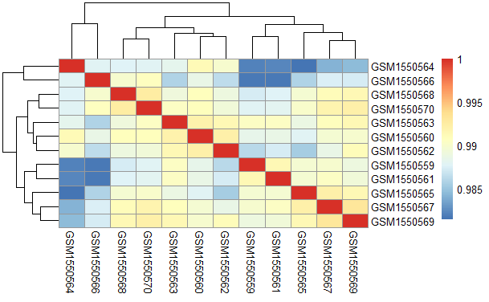

```r
library(pheatmap)
## argument use="c" stops an error if there are any missing data points

corMatrix <- cor(exprs(gse),use="c")
pheatmap(corMatrix)
```

Check if row and column names match the correlation matrix otherwise format match.

```r
rownames(sampleInfo)
```

```
 [1] "GSM1550559" "GSM1550560" "GSM1550561" "GSM1550562" "GSM1550563"
 [6] "GSM1550564" "GSM1550565" "GSM1550566" "GSM1550567" "GSM1550568"
[11] "GSM1550569" "GSM1550570"
```

```r
colnames(corMatrix)
```

```
 [1] "GSM1550559" "GSM1550560" "GSM1550561" "GSM1550562" "GSM1550563"
 [6] "GSM1550564" "GSM1550565" "GSM1550566" "GSM1550567" "GSM1550568"
[11] "GSM1550569" "GSM1550570"
```

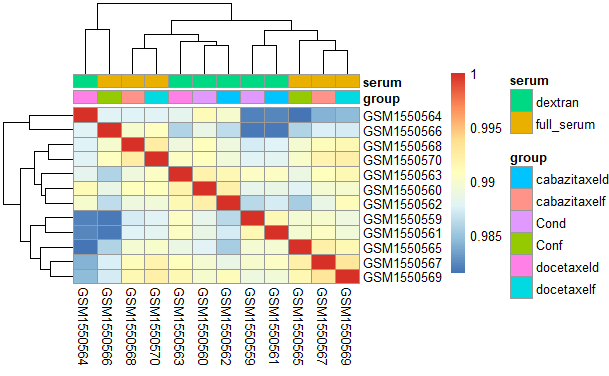

```r
## If not, force the rownames to match the columns
#rownames(sampleInfo) <- colnames(corMatrix)

pheatmap(corMatrix, annotation_col= sampleInfo)
```

Another way is to use PCA. It requires the data to be transposed, so that the genelist in the column, and rownames in samples.

```r
if (!require("ggplot2", quietly = TRUE))
    install.packages("ggplot2")

if (!require("ggrepel", quietly = TRUE))
    install.packages("ggrepel")
```

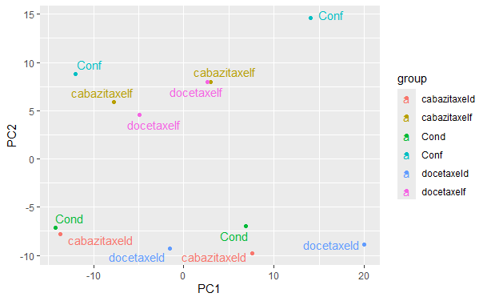

```r
#make PCA
library(ggplot2)
library(ggrepel)
## MAKE SURE TO TRANSPOSE THE EXPRESSION MATRIX

pca <- prcomp(t(exprs(gse)))

## Join the PCs to the sample information
cbind(sampleInfo, pca$x) %>%
  ggplot(aes(x = PC1, y=PC2, col=group, label=paste("",group))) + geom_point() + geom_text_repel()
```

## Differential expression analysis

We’ll use the limma (Linear models for microarray) package to perform differential expressions. We need to tell limma what sample groups we want to compare. I choose sampleInfo$group. A design matrix will be created, this is a matrix of 0 and 1, one row for each sample and one column for each sample group. We’ll rename column names.

Now, let’s check if the expression data contain any lowly-expressed genes, this will affect the quality of DE analysis. A big problem in doing statistical analysis like limma is the inference of type 1 statistical errors, also called false positive. One simple way to reduce the possibility for type 1 errors is to do fewer comparisons, by filtering the data. For example, we know that not all genes are expressed in all tissues and many genes will not be expressed in any sample. As a result, in DGE analysis, it makes sense to remove the genes that are likely not expressed at all.

We can see that around half of the genes are not qualified as an “expressed” gene here, which makes sense, bcoz our cut-off is the median value.

```r
design <- model.matrix(~0 + sampleInfo$group)
design
```

```
   sampleInfo$groupcabazitaxeld sampleInfo$groupcabazitaxelf
1                             0                            0
2                             0                            0
3                             1                            0
4                             1                            0
5                             0                            0
6                             0                            0
7                             0                            0
8                             0                            0
9                             0                            1
10                            0                            1
11                            0                            0
12                            0                            0
   sampleInfo$groupCond sampleInfo$groupConf sampleInfo$groupdocetaxeld
1                     1                    0                          0
```

[output cut: 29 more lines]

```r
## the column names are a bit ugly, so we will rename
colnames(design) <- c("Cabazitaxeld","Cabazitaxelf","Cond","Conf","Docetaxeld","Docetaxelf")

design
```

```
   Cabazitaxeld Cabazitaxelf Cond Conf Docetaxeld Docetaxelf
1             0            0    1    0          0          0
2             0            0    1    0          0          0
3             1            0    0    0          0          0
4             1            0    0    0          0          0
5             0            0    0    0          1          0
6             0            0    0    0          1          0
7             0            0    0    1          0          0
8             0            0    0    1          0          0
9             0            1    0    0          0          0
10            0            1    0    0          0          0
11            0            0    0    0          0          1
12            0            0    0    0          0          1
attr(,"assign")
[1] 1 1 1 1 1 1
attr(,"contrasts")
attr(,"contrasts")$`sampleInfo$group`
[1] "contr.treatment"
```

```r
## calculate median expression level
cutoff <- median(exprs(gse))

## TRUE or FALSE for whether each gene is "expressed" in each sample
is_expressed <- exprs(gse) > cutoff

## Identify genes expressed in more than 2 samples
keep <- rowSums(is_expressed) > 3

## check how many genes are removed / retained.
table(keep)
```

```
keep
FALSE  TRUE
20965 23664
```

```r
## subset to just those expressed genes
gse <- gse[keep,]
```

Here there is a little extra step to find out the outliers. This has to be done carefully so the filtered data won’t be too biased. We calculate ‘weights’ to define the reliability of each sample. The ‘arrayweights’ function will assign a score to each sample, with a value of 1 implying equal weight. Samples with score less than 1 are down-weighed, or else up-weighed.

```r
# coping with outliers
## calculate relative array weights
aw <- arrayWeights(exprs(gse),design)
aw
```

```
        1         2         3         4         5         6         7
0.9704842 0.9704842 0.8790788 0.8790788 0.9799805 0.9799805 0.8296341
        8         9        10        11        12
0.8296341 1.1632620 1.1632620 1.2393733 1.2393733
```

Now we have a design matrix, we need to estimate the coefficients. For this design, we will essentially average the replicate arrays for each sample level. In addition, we will calculate standard deviations for each gene, and the average intensity for the genes across all microarrays.

We are ready to tell limma which pairwise contrasts that we want to make. For this experiment, we are going to contrast treatment (there are two types of texane drugs) and control in each serum type. So there are 4 contrasts to specify.

To do the statistical comparisons, Limma uses Bayesian statistics to minimize type 1 error. The eBayes function performs the tests. To summarize the results of the statistical test, ‘topTable’ will adjust the p-values and return the top genes that meet the cutoffs that you supply as arguments; while ‘decideTests’ will make calls for DEGs by adjusting the p-values and applying a logFC cutoff similar to topTable.

```r
## Fitting the coefficients
fit <- lmFit(exprs(gse), design,
             weights = aw)

head(fit$coefficients)
```

```
         Cabazitaxeld Cabazitaxelf     Cond     Conf Docetaxeld
16657436     4.604278     4.590902 4.539703 4.606668   4.569910
16657440     5.073400     5.194166 5.274991 5.001295   5.230574
16657450     6.606782     6.532054 6.571707 6.754964   6.854709
16657469     5.318536     5.298899 5.358629 5.191262   5.398528
16657476     5.410581     5.443410 5.358263 5.343908   5.516173
16657480     4.481099     4.454008 4.487220 4.453781   4.418727
         Docetaxelf
16657436   4.504447
16657440   5.016408
16657450   6.495389
16657469   5.356415
16657476   5.335881
16657480   4.379055
```

```r
## Making comparisons between samples, can define multiple contrasts
contrasts <- makeContrasts(Docetaxeld - Cond, Cabazitaxeld - Cond, Docetaxelf - Conf, Cabazitaxelf - Conf, levels = design)

fit2 <- contrasts.fit(fit, contrasts)
fit2 <- eBayes(fit2)


topTable(fit2)
```

|  | Docetaxeld...Cond | Cabazitaxeld...Cond | Docetaxelf...Conf | Cabazitaxelf...Conf | AveExpr | F | P.Value | adj.P.Val |
| --- | --- | --- | --- | --- | --- | --- | --- | --- |
| 16681891 | -0.427866483 | 0.55288766 | -0.02322651 | -0.1414628 | 5.625598 | 43.01843 | 2.992480e-06 | 0.07081404 |
| 16840609 | 0.573090433 | -0.20083754 | -0.21477778 | -0.3278230 | 5.769203 | 18.87958 | 1.217387e-04 | 0.99909331 |
| 17017165 | 0.116986540 | -0.32582451 | -0.44959204 | -0.3710638 | 5.244400 | 14.18263 | 4.059196e-04 | 0.99909331 |
| 16782010 | 0.178206104 | -0.01891042 | -0.29766696 | 0.2850105 | 4.440952 | 14.12466 | 4.128114e-04 | 0.99909331 |
| 17099705 | -0.437302094 | 0.02759174 | -0.16952565 | 0.2776297 | 6.750407 | 13.62541 | 4.783683e-04 | 0.99909331 |
| 16691877 | -0.149430506 | -0.18664917 | -0.90866405 | -0.5849898 | 4.667038 | 11.52373 | 9.376105e-04 | 0.99909331 |
| 16959582 | -0.006190599 | -0.17371327 | 0.40620159 | 0.3098904 | 5.531461 | 11.26699 | 1.024647e-03 | 0.99909331 |
| 16970902 | -0.416408859 | 0.01679171 | -0.02017417 | -0.1618155 | 5.237839 | 11.18970 | 1.052724e-03 | 0.99909331 |
| 16936214 | -0.112315413 | 0.12707501 | -0.28387277 | -0.6271607 | 5.482977 | 11.17492 | 1.058196e-03 | 0.99909331 |
| 17009126 | -0.645309985 | -0.59167505 | -0.39348344 | -0.3389764 | 4.940635 | 11.00507 | 1.123616e-03 | 0.99909331 |

```r
topTable1 <- topTable(fit2, coef=1)
topTable2 <- topTable(fit2, coef=2)
topTable3 <- topTable(fit2, coef=3)
topTable4 <- topTable(fit2, coef=4)

#if we want to know how many genes are differentially expressed overall, we can use the decideTest function.
summary(decideTests(fit2))
```

```
       Docetaxeld - Cond Cabazitaxeld - Cond Docetaxelf - Conf
Down                   0                   0                 0
NotSig             23664               23664             23664
Up                     0                   0                 0
       Cabazitaxelf - Conf
Down                     0
NotSig               23664
Up                       0
```

```r
table(decideTests(fit2))
```

```
    0
94656
```

## Further visualization with gene annotation

Now we want to know the gene name associated with the gene ID. The annotation data can be retrieved with the ‘fData’ function. Let’s select the ID, GB_ACC, this is genbank accession ID. Add into fit2 table.

```r
anno <- fData(gse)
head(anno)
```

|  | ID | RANGE_STRAND | RANGE_START | RANGE_END | total_probes | GB_ACC | SPOT_ID | RANGE_GB |
| --- | --- | --- | --- | --- | --- | --- | --- | --- |
| 16657436 | 16657436 | + | 12190 | 13639 | 25 | NR_046018 | chr1:12190-13639 | NC_000001.10 |
| 16657440 | 16657440 | + | 29554 | 31109 | 28 |  | chr1:29554-31109 | NC_000001.10 |
| 16657450 | 16657450 | + | 317811 | 328581 | 36 | NR_024368 | chr1:317811-328581 | NC_000001.10 |
| 16657469 | 16657469 | + | 329790 | 342507 | 27 |  | chr1:329790-342507 | NC_000001.10 |
| 16657476 | 16657476 | + | 459656 | 461954 | 27 | NR_029406 | chr1:459656-461954 | NC_000001.10 |
| 16657480 | 16657480 | + | 523009 | 532878 | 12 |  | chr1:523009-532878 | NC_000001.10 |

```r
anno <- select(anno,ID,GB_ACC)
fit2$genes <- anno

topTable(fit2)
```

|  | ID | GB_ACC | Docetaxeld...Cond | Cabazitaxeld...Cond | Docetaxelf...Conf | Cabazitaxelf...Conf | AveExpr | F | P.Value | adj.P.Val |
| --- | --- | --- | --- | --- | --- | --- | --- | --- | --- | --- |
| 16681891 | 16681891 | NM_001013692 | -0.427866483 | 0.55288766 | -0.02322651 | -0.1414628 | 5.625598 | 43.01843 | 2.992480e-06 | 0.07081404 |
| 16840609 | 16840609 |  | 0.573090433 | -0.20083754 | -0.21477778 | -0.3278230 | 5.769203 | 18.87958 | 1.217387e-04 | 0.99909331 |
| 17017165 | 17017165 |  | 0.116986540 | -0.32582451 | -0.44959204 | -0.3710638 | 5.244400 | 14.18263 | 4.059196e-04 | 0.99909331 |
| 16782010 | 16782010 |  | 0.178206104 | -0.01891042 | -0.29766696 | 0.2850105 | 4.440952 | 14.12466 | 4.128114e-04 | 0.99909331 |
| 17099705 | 17099705 | NR_039696 | -0.437302094 | 0.02759174 | -0.16952565 | 0.2776297 | 6.750407 | 13.62541 | 4.783683e-04 | 0.99909331 |
| 16691877 | 16691877 |  | -0.149430506 | -0.18664917 | -0.90866405 | -0.5849898 | 4.667038 | 11.52373 | 9.376105e-04 | 0.99909331 |
| 16959582 | 16959582 |  | -0.006190599 | -0.17371327 | 0.40620159 | 0.3098904 | 5.531461 | 11.26699 | 1.024647e-03 | 0.99909331 |
| 16970902 | 16970902 |  | -0.416408859 | 0.01679171 | -0.02017417 | -0.1618155 | 5.237839 | 11.18970 | 1.052724e-03 | 0.99909331 |
| 16936214 | 16936214 | NR_037440 | -0.112315413 | 0.12707501 | -0.28387277 | -0.6271607 | 5.482977 | 11.17492 | 1.058196e-03 | 0.99909331 |
| 17009126 | 17009126 |  | -0.645309985 | -0.59167505 | -0.39348344 | -0.3389764 | 4.940635 | 11.00507 | 1.123616e-03 | 0.99909331 |

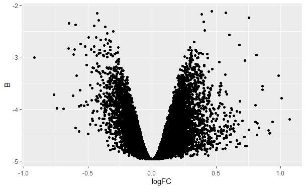

```r
## Create volcano plot
full_results1 <- topTable(fit2, coef=1, number=Inf)
library(ggplot2)
ggplot(full_results1,aes(x = logFC, y=B)) + geom_point()
```

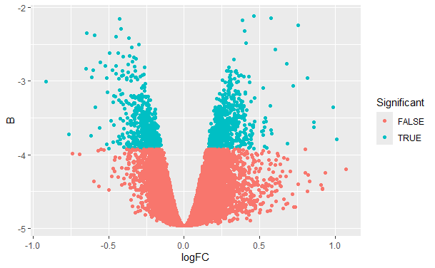

```r
## change according to your needs
p_cutoff <- 0.05
fc_cutoff <- 1


full_results1 %>%
  mutate(Significant = P.Value < p_cutoff, abs(logFC) > fc_cutoff ) %>%
  ggplot(aes(x = logFC, y = B, col=Significant)) + geom_point()
```

## Further visualization of selected gene

I think at this point, we are quite clear about data structure of GSE data. It has an experiment data, pData; the expression data, exprs; and also annotation data, fData. And we have learned how to check the expression data, normalize them, and perform differential expression analysis.

Now, with the differential expression gene tables, there are some downstream analyses that we can continue, such as to export a full table of DE genes, to generate a heatmap for your selected genes, get the gene list for a particular pathway, or survival analysis (but this is only for those clinical data).

Here, I just want to look into the fold change data of a selected gene, whether it is significantly differential expressed or not.

```r
## Get the results for particular gene of interest
#GB_ACC for Nkx3-1 is NM_001256339 or NM_006167
##no NM_001256339 in this data
full_results2 <- topTable(fit2, coef=2, number=Inf)
full_results3 <- topTable(fit2, coef=3, number=Inf)
full_results4 <- topTable(fit2, coef=4, number=Inf)
filter(full_results1, GB_ACC == "NM_006167")
```

|  | ID | GB_ACC | logFC | AveExpr | t | P.Value | adj.P.Val | B |
| --- | --- | --- | --- | --- | --- | --- | --- | --- |
| 17075536 | 17075536 | NM_006167 | -0.2379718 | 8.055042 | -3.056052 | 0.01219317 | 0.9819604 | -3.374675 |

```r
filter(full_results2, GB_ACC == "NM_006167")
```

|  | ID | GB_ACC | logFC | AveExpr | t | P.Value | adj.P.Val | B |
| --- | --- | --- | --- | --- | --- | --- | --- | --- |
| 17075536 | 17075536 | NM_006167 | -0.09964001 | 8.055042 | -1.244539 | 0.2418169 | 0.9999406 | -4.561219 |

```r
filter(full_results3, GB_ACC == "NM_006167")
```

|  | ID | GB_ACC | logFC | AveExpr | t | P.Value | adj.P.Val | B |
| --- | --- | --- | --- | --- | --- | --- | --- | --- |
| 17075536 | 17075536 | NM_006167 | 0.02902121 | 8.055042 | 0.3762533 | 0.7146269 | 0.9999674 | -4.926393 |

```r
filter(full_results4, GB_ACC == "NM_006167")
```

|  | ID | GB_ACC | logFC | AveExpr | t | P.Value | adj.P.Val | B |
| --- | --- | --- | --- | --- | --- | --- | --- | --- |
| 17075536 | 17075536 | NM_006167 | 0.01019426 | 8.055042 | 0.1304658 | 0.8987979 | 0.9998834 | -4.95523 |